# AndresGibu_Tarea_Ejercicio_Series_Temporales

## observado. Representarlas gráficamente. (1)

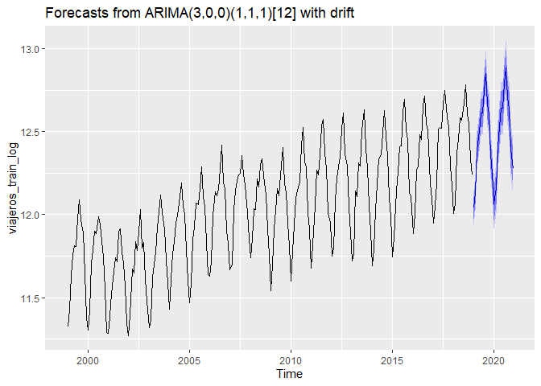

```r
autoplot(forecast(fitvviajeros2),h=12)
```

```r
predi3_prima<-forecast(fitvviajeros)
cbind("prediccion" =exp(predi3_prima$mean),
"L" = exp(predi3_prima$lower),
"U" = exp(predi3_prima$upper)) %>%print()
```

```
##          prediccion    L.80%    L.95%    U.80%    U.95%
## Jan 2019   169450.5 158587.2 153121.3 181058.0 187521.1
## Feb 2019   185766.2 172517.0 165890.2 200033.0 208023.7
## Mar 2019   239482.0 219309.6 209328.2 261509.9 273979.4
## Apr 2019   268438.8 243785.4 231664.8 295585.4 311050.3
## May 2019   300265.6 270316.6 255691.5 333532.7 352610.3
## Jun 2019   298968.5 267237.7 251827.3 334466.9 354934.4
## Jul 2019   344773.6 306123.5 287449.5 388303.5 413529.4
## Aug 2019   378576.7 334139.5 312767.9 428923.6 458232.1
## Sep 2019   314847.4 276363.2 257933.3 358690.5 384319.7
## Oct 2019   294021.1 256783.4 239019.9 336658.8 361678.7
## Nov 2019   228944.2 199015.5 184790.2 263373.6 283648.4
## Dec 2019   205672.5 178012.8 164909.8 237630.0 256510.9
## Jan 2020   169676.4 145312.7 133865.2 198125.1 215067.8
## Feb 2020   186034.2 158325.6 145369.5 218592.2 238074.3
## Mar 2020   238160.5 201236.5 184067.3 281859.5 308150.5
## Apr 2020   268872.5 225836.9 205918.1 320108.9 351073.6
## May 2020   299614.1 250197.7 227428.5 358790.7 394711.3
## Jun 2020   298784.8 248193.6 224978.2 359688.4 396804.4
## Jul 2020   346749.1 286606.8 259114.9 419511.9 464021.7
## Aug 2020   379476.1 312211.5 281574.0 461232.6 511418.4
## Sep 2020   315600.3 258533.4 232628.3 385263.7 428166.1
## Oct 2020   294274.7 240085.6 215564.4 360694.6 401724.9
## Nov 2020   228168.5 185441.9 166164.9 280739.5 313308.3
## Dec 2020   204480.3 165592.5 148096.5 252500.5 282330.7
```

```r
predi3<-forecast(fitvviajeros2)
cbind("prediccion" =exp(predi3$mean),
"L" = exp(predi3$lower),
"U" = exp(predi3$upper)) %>%print()
```

```
##          prediccion    L.80%    L.95%    U.80%    U.95%
## Jan 2019   169251.3 158721.0 153414.5 180480.1 186722.8
## Feb 2019   185909.4 173589.1 167401.2 199104.1 206464.0
## Mar 2019   240437.4 222982.6 214261.5 259258.5 269811.1
## Apr 2019   268827.5 248155.8 237864.3 291221.2 303821.3
## May 2019   300786.6 276723.3 264774.4 326942.3 341696.9
## Jun 2019   300333.1 275557.8 263280.9 327335.9 342599.7
## Jul 2019   345552.6 316389.0 301960.7 377404.3 395437.5
## Aug 2019   380609.6 347917.9 331764.5 416373.1 436646.0
## Sep 2019   317527.6 289880.4 276233.0 347811.6 364995.4
## Oct 2019   297375.0 271206.2 258298.7 326069.0 342363.0
## Nov 2019   233446.0 212730.9 202519.9 256178.2 269094.7
## Dec 2019   209271.0 190578.8 181369.4 229796.6 241465.0
## Jan 2020   173633.1 157290.8 149271.8 191673.3 201970.1
## Feb 2020   191138.1 172896.7 163955.9 211304.1 222826.9
## Mar 2020   245760.3 221925.9 210259.2 272154.4 287255.5
## Apr 2020   276470.4 249336.3 236067.6 306557.4 323788.2
## May 2020   308813.7 278229.0 263284.3 342760.5 362216.4
## Jun 2020   309568.3 278683.9 263602.2 343875.3 363549.7
## Jul 2020   359265.8 323217.8 305623.3 399334.2 422323.6
## Aug 2020   394652.8 354874.1 335466.2 438890.3 464281.7
## Sep 2020   329478.6 296149.3 279893.1 366558.8 387848.5
## Oct 2020   308279.6 277005.4 261755.4 343084.6 363072.9
## Nov 2020   241074.3 216562.2 204611.9 268360.8 284034.4
## Dec 2020   215493.4 193542.6 182842.6 239933.9 253974.8
```

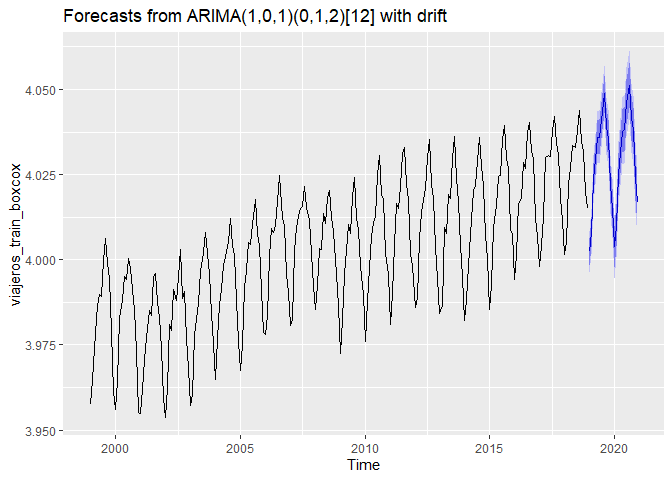

```r
autoplot(forecast(fitvviajeros2_boxcox),h=12)
```

```r
predi4_prima<-forecast(fitvviajeros_boxcox)
cbind("prediccion" =(predi4_prima$mean*lambda+1)^(1/lambda),
"L" = (predi4_prima$lower*lambda+1)^(1/lambda),
"U" = (predi4_prima$upper*lambda+1)^(1/lambda)) %>%print()
```

```
##          prediccion    L.80%    L.95%    U.80%    U.95%
## Jan 2019   167475.2 156301.9 150759.7 179651.7 186540.3
## Feb 2019   185200.9 171103.3 164176.9 200761.2 209652.2
## Mar 2019   241584.6 218582.6 207500.8 267651.3 282857.3
## Apr 2019   272051.6 243043.8 229234.0 305457.8 325194.5
## May 2019   305951.5 269624.4 252550.0 348519.4 374017.4
## Jun 2019   305182.4 266643.9 248675.5 350839.5 378427.7
## Jul 2019   354844.9 305965.4 283455.8 413740.6 449811.5
## Aug 2019   391351.6 333720.2 307454.4 461788.7 505423.1
## Sep 2019   322087.1 274703.5 253104.7 379986.3 415847.3
## Oct 2019   299484.4 254526.9 234101.4 354669.0 388973.3
## Nov 2019   230637.5 196820.7 181397.7 271928.6 297487.8
## Dec 2019   205324.3 175095.1 161317.4 242268.4 265153.6
## Jan 2020   167828.5 142660.8 131224.5 198714.0 217909.7
## Feb 2020   185483.2 156029.2 142775.3 222118.8 245136.1
## Mar 2020   240812.6 198834.4 180270.7 294299.4 328564.6
## Apr 2020   273054.4 222657.1 200628.8 338319.0 380683.9
## May 2020   306200.9 246632.4 220892.8 384589.6 436143.1
## Jun 2020   305926.1 244880.6 218655.7 386915.1 440534.5
## Jul 2020   358278.2 282702.0 250666.0 460448.3 529141.7
## Aug 2020   393997.2 307464.9 271161.0 512694.6 593462.0
## Sep 2020   323889.7 254164.5 224760.0 418834.6 483051.1
## Oct 2020   300553.7 235664.8 208320.1 389005.4 448881.7
## Nov 2020   230223.6 182336.2 161966.7 294646.5 337787.6
## Dec 2020   204257.7 162140.8 144187.7 260748.4 298484.8
```

```r
predi4<-forecast(fitvviajeros2_boxcox)
cbind("prediccion" =(predi4$mean*lambda+1)^(1/lambda),
"L" = (predi4$lower*lambda+1)^(1/lambda),
"U" = (predi4$upper*lambda+1)^(1/lambda)) %>%print()
```

```
##          prediccion    L.80%    L.95%    U.80%    U.95%
## Jan 2019   166034.9 155291.9 149952.4 177710.9 184302.4
## Feb 2019   183093.0 170043.1 163599.9 197402.3 205536.6
## Mar 2019   241653.1 222258.0 212768.9 263181.9 275538.1
## Apr 2019   269352.3 246202.9 234942.9 295250.2 310205.4
## May 2019   304836.0 276937.2 263444.7 336289.6 354563.8
## Jun 2019   305665.7 276855.9 262962.2 338270.3 357270.1
## Jul 2019   355598.5 320112.7 303097.6 396071.7 419801.7
## Aug 2019   394196.6 353156.3 333566.5 441291.2 469036.8
## Sep 2019   325087.2 292103.8 276316.1 362794.8 384944.3
## Oct 2019   303137.5 272423.2 257719.5 338244.2 358862.8
## Nov 2019   234905.6 212135.0 201184.2 260772.5 275890.7
## Dec 2019   207490.7 187720.7 178196.7 229896.9 242968.6
## Jan 2020   170463.0 154045.6 146145.1 189096.5 199979.5
## Feb 2020   189648.3 170590.0 161458.5 211406.6 224173.8
## Mar 2020   248232.7 221344.1 208566.0 279273.0 297646.9
## Apr 2020   280837.5 249163.4 234181.8 317636.2 339529.1
## May 2020   316467.6 279415.0 261969.0 359782.0 385678.0
## Jun 2020   318730.5 280991.1 263246.7 362932.1 389398.7
## Jul 2020   375379.6 328944.3 307234.2 430185.7 463203.0
## Aug 2020   415282.6 362403.5 337776.6 478026.0 515985.0
## Sep 2020   341564.4 299616.8 279986.1 391009.6 420766.6
## Oct 2020   317602.9 279005.2 260917.4 363014.8 390304.1
## Nov 2020   243988.5 215860.3 202591.0 276785.3 296353.0
## Dec 2020   213912.8 189854.1 178470.7 241851.4 258467.2
```

Vemos que las predicciones de ambos modelos (rediciendo variabildidad con logartimo y con boxcox) está cercanas entre sí.

## 8. Comparar las predicciones obtenidas con cada uno de los métodos con los valores

## observados que habíamos reservado antes. Conclusiones. (0.5)

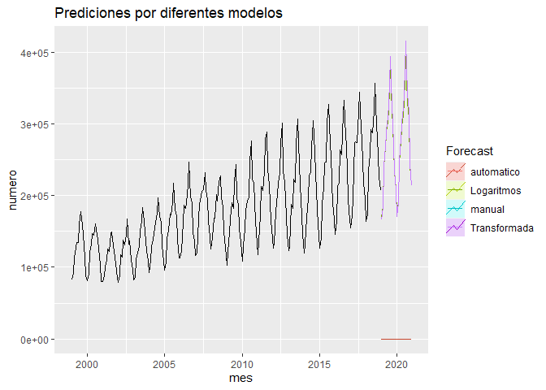

```r
autoplot(viajeros_train) +
autolayer(forecast(fitvviajeros), series="manual", PI=FALSE) +
autolayer(forecast(fitvviajeros2), series="automatico", PI=FALSE) +
autolayer(exp(predi3$mean), series="Logaritmos")+
autolayer((predi4$mean*lambda+1)^(1/lambda), series="Transformada")+
ggtitle("Prediciones por diferentes modelos ") + xlab("mes") +
ylab("numero") +
guides(colour=guide_legend(title="Forecast"))
```

Visualmente es difícil distinguir.

```r
predicciones_prima<-as.data.frame(exp(predi3_prima$mean))
rmse(predicciones_prima$x[1:12], serie_original_2019$Viajeros)
```

```
## [1] 7755.395
```

```r
predicciones<-as.data.frame(exp(predi3$mean))
rmse(predicciones$x[1:12], serie_original_2019$Viajeros)
```

```
## [1] 8433.941
```

```r
predicciones_boxcox<-as.data.frame((predi4$mean*lambda+1)^(1/lambda))
rmse(predicciones_boxcox$x[1:12], serie_original_2019$Viajeros)
```

```
## [1] 13953.27
```

```r
predicciones_prima_boxcox<-as.data.frame((predi4_prima$mean*lambda+1)^(1/lambda))
rmse(predicciones_prima_boxcox$x[1:12], serie_original_2019$Viajeros)
```

```
## [1] 12865.1
```

Estos son los resultados de los 4 modelos:

Los dos primeros modelos se obtenieron reduciendo la variabilidad a travé de una logaritmo. Los dos siguientes con una transformación con lambda.

Recordemos que el modelo obtenido por auto arima con la transformación lambda obtuvo el menor AICc pero no el menor RMSE y más bien el modelo obtenido a mano con la transformación logarítmica obtuvo más AICc pero menor RMSE.

Se propone tomar el modelo auto arima con transformación logaritmica por que balancea complejidad con precisión.

Finalmente el modelo ARIMA escogido nos da mejor RMSE 8433.941 vs 9672.786 comparado con el de suavización exponenecial.